# DRAFT: The FAUNMAP Constituent Database

FAUNMAP is one of the original Neotoma Constituent Databases. FAUNMAP was originally developed by Russ Graham and Ernest Lundelius in the early 1990s with [funding from the NSF](https://www.nsf.gov/awardsearch/showAward?AWD_ID=9005144). FAUNMAP initially aggregated mammalian occurrences from across the United States for the past 50,000 years. In the late 1990s, the temporal reach of the database was extended to encompass the past five million years. FAUNMAP does contain some data on vertebrate taxa outside mammals (as well as a few plant and invertebrate datasets!), but mammals are its primary focus.

FAUNMAP currently contains 6956 datasets from 4847 sites from the locations mapped below.

[interactive chart not shown]

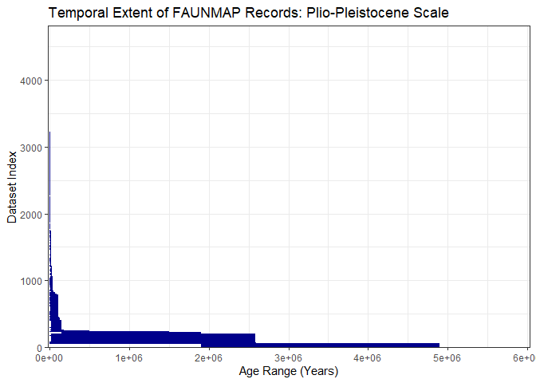

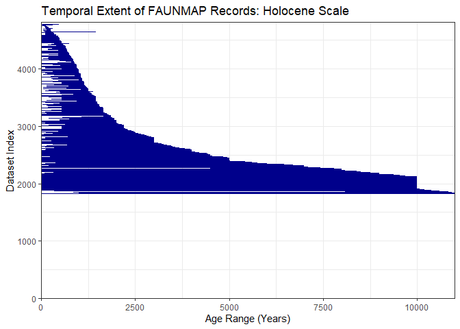

Most FAUNMAP datasets are vertebrate fauna or geochronologic, with a few outlying dataset kinds.

| datasets | number |
| --- | --- |
| vertebrate fauna | 4838 |
| geochronologic | 2103 |
| macroinvertebrate | 12 |
| plant macrofossil | 2 |
| ostracode | 1 |

In 2018, thousands of new datasets were uploaded to FAUNMAP.

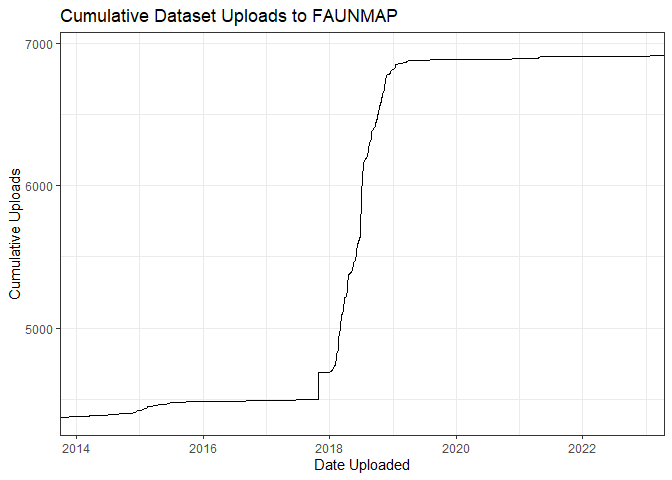

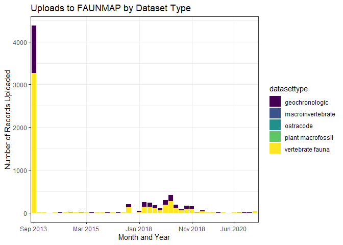

Prior to 2018, the researcher associated with the most FAUNMAP datasets was John H. Brumley, who had 29 datasets in the database.

| contactid | contactname | n |
| --- | --- | --- |
| 1958 | Brumley, John H. | 29 |
| 4937 | Rushworth, Carol A. | 28 |
| 487 | Burns, James A. | 27 |
| 4500 | Rains, R. Bruce | 21 |
| 4497 | Young, Robert R. | 19 |
| 4514 | Reeves, Brian O.K. | 19 |
| 1633 | Wilson, Michael Clayton | 16 |
| 379 | McNeely, R. | 15 |
| 2757 | Morlan, Richard E. | 15 |
| 3276 | Wolfe, Stephen A. | 15 |

[output cut: 322 more lines]

Currently, the researcher with the most data uploaded to FAUNMAP is Charles Richard Harington, who is associated with 259 datasets in the database.

| contactid | contactname | n |
| --- | --- | --- |
| 2390 | Harington, Charles Richard | 259 |
| 2757 | Morlan, Richard E. | 146 |
| 4812 | Wilmeth, Roscoe | 131 |
| 1734 | Jefferson, George T. | 123 |
| 6317 | Widga, Christopher C. | 122 |
| 11439 | Hodgins, Gregory | 114 |
| 150 | McDonald, H. Gregory | 105 |
| 1958 | Brumley, John H. | 97 |
| 3271 | Wittenberg, Juergen | 84 |
| 2605 | Livingston, Stephanie D. | 79 |

[output cut: 1249 more lines]